# Interactive Plant Identification in R

Heather Kates

April 24, 2015

# Project Goal: Create an interactive key for identifying plant families

1. Requiring specific code for each set of characters
2. Reading user input for each set of characters
3. Reading user input for each character

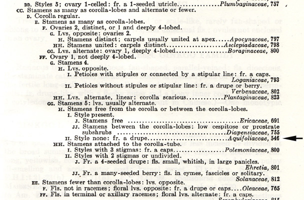

##### Traditional dichotomous key

# Data and input to subset data

**Data**

```
##           Family      habit leaf.arrangement stipules ovary.position
## 1       Apiaceae herbaceous        alternate   absent       inferior
## 2     Araliaceae      woody         opposite  present       superior
## 3 Pittosporaceae herbaceous        alternate   absent       superior
## 4  Aquifoliaceae      woody        alternate  present       superior
## 5     Asteraceae herbaceous         opposite   absent       inferior
## 6  Campanulaceae herbaceous        alternate   absent       inferior
##   inflorescence floral.symmetry
## 1         umbel       bilateral
## 2      terminal          radial
## 3         spike          radial
## 4         spike      bilaterial
## 5         umbel      bilaterial
## 6         umbel      bilaterial
```

**Input** herbaceous alternate absent inferior umbel bilateral

**Output** Family: Apiaceae

# 1. Learn a little about plant family characteristics

#### What proportion of plant families are woody?

```r
plant_families <- read.csv(file="Plant_families_for_R.csv")
prop <- nrow(subset(plant_families, habit == "woody"))/(nrow(plant_families))
percent <- ((signif(prop, digits=3))*100)
cat(percent, "% of the families are woody")
```

```
## 30.8 % of the families are woody
```

#### What proportion of plant families have stipules?

```r
prop <- nrow(subset(plant_families, stipules == "present"))/nrow(plant_families)
percent <- ((signif(prop, digits=3))*100)
cat(percent, "% of the families have stipules")
```

```
## 11.5 % of the families have stipules
```

#### What proportion of the plant families are vines?

```r
prop <- nrow(subset(plant_families, habit == "vine"))/nrow(plant_families)
percent <- ((signif(prop, digits=3))*100)
cat(percent, "% of the families are vines")
```

```
## 7.69 % of the families are vines
```

# Use the same approach to identify plant families from a set of character

### I have a plant that is a vine with no stipules. What family could it be?

```r
Vine_nostipule_families <- subset(plant_families, habit =="vine" & stipules == "absent")
Family <- as.vector(Vine_nostipule_families$Family)
cat("Possible Families:", Family)
```

```
## Possible Families: Bignoniaceae Convolvulaceae
```

But this requires the code:

```r
subset(plant_families, habit =="vine" & stipules == "absent")
```

to be rewritten for each query! Instead, we can prompt the user to enter these values and update the code

# Prompting user to enter values that will update the code

```r
prompt <- "Describe your plant:
habit(woody/herbaceous/vine)\nstipules(present/absent)\nleaf arrangement(opposite/alternate)
ovary position(superior/inferior)\ninflorescence(umbel/head/cyme/terminal)\nfloral symmetry(radial/zygomorphic/actinomorphic)"
Character_list <- as.vector(strsplit(readline(prompt), " ")[[1]])
```

```
## Describe your plant:
## habit(woody/herbaceous/vine)
## stipules(present/absent)
## leaf arrangement(opposite/alternate)
## ovary position(superior/inferior)
## inflorescence(umbel/head/cyme/terminal)
## floral symmetry(radial/zygomorphic/actinomorphic)
```